# Analyze weather influence on electricity consumption and predict electricity consumption based on weather features

# Data cleaning

Summary and icon were dropped due to being general and useless because we have the detailed weather features

```python
# meter_data 1
meter_data1=meter_data1.drop(['icon','summary'],axis=1)
```

```python
#Test of meter_data 1 after drop
meter_data1.head()
```

| Date & Time | temperature | humidity | visibility | apparentTemperature | pressure | windSpeed | cloudCover | windBearing | precipIntensity | dewPoint | precipProbability |
| --- | --- | --- | --- | --- | --- | --- | --- | --- | --- | --- | --- |
| 2014-01-01 00:00:00 | 16.67 | 0.53 | 10.0 | 3.95 | 1022.69 | 11.23 | 0.00 | 271.0 | 0.0 | 2.41 | 0.0 |
| 2014-01-01 01:00:00 | 16.19 | 0.52 | 10.0 | 4.18 | 1022.58 | 9.92 | 0.02 | 268.0 | 0.0 | 1.68 | 0.0 |
| 2014-01-01 02:00:00 | 15.69 | 0.55 | 10.0 | 4.41 | 1023.61 | 8.72 | 0.00 | 266.0 | 0.0 | 2.59 | 0.0 |
| 2014-01-01 03:00:00 | 15.29 | 0.58 | 10.0 | 4.29 | 1024.31 | 8.25 | 0.00 | 269.0 | 0.0 | 3.29 | 0.0 |
| 2014-01-01 04:00:00 | 15.37 | 0.60 | 10.0 | 5.12 | 1024.51 | 7.38 | 0.06 | 266.0 | 0.0 | 3.95 | 0.0 |

```python
#meter_data2
meter_data2=meter_data2.drop(['use [kW]','gen [kW]'],axis=1) # drop unwanted columns due having zero values
meter_data2=meter_data2.resample('H').mean() # to unify time observations into hourly samples
```

```python
#test of meter_data2
meter_data2.head()
```

| Date & Time | FurnaceHRV [kW] | CellarOutlets [kW] | WashingMachine [kW] | FridgeRange [kW] | DisposalDishwasher [kW] | KitchenLights [kW] | BedroomOutlets [kW] | BedroomLights [kW] | MasterOutlets [kW] | MasterLights [kW] | DuctHeaterHRV [kW] |
| --- | --- | --- | --- | --- | --- | --- | --- | --- | --- | --- | --- |
| 2014-01-01 00:00:00 | 0.188748 | 0.059672 | 0.005683 | 0.050515 | 0.005490 | 0.008677 | 0.020511 | 0.006884 | 0.049120 | 0.010139 | 0.329129 |
| 2014-01-01 01:00:00 | 0.158467 | 0.059220 | 0.005653 | 0.048434 | 0.005477 | 0.003123 | 0.020511 | 0.004873 | 0.052081 | 0.010089 | 0.328092 |
| 2014-01-01 02:00:00 | 0.111822 | 0.042478 | 0.005586 | 0.043357 | 0.005429 | 0.003115 | 0.020398 | 0.004841 | 0.048918 | 0.010002 | 0.325534 |
| 2014-01-01 03:00:00 | 0.068529 | 0.041506 | 0.005560 | 0.044769 | 0.005432 | 0.003131 | 0.020532 | 0.004846 | 0.048724 | 0.010033 | 0.323582 |
| 2014-01-01 04:00:00 | 0.074540 | 0.038502 | 0.005565 | 0.044778 | 0.005469 | 0.004444 | 0.020642 | 0.004870 | 0.048807 | 0.010085 | 0.324708 |

```python
#meter_data3
meter_data3=meter_data3[['ElectricRange [kW]','Dryer [kW]','GarageMudroomLights [kW]']] #use only wanted columns
meter_data3=meter_data3.resample('H').mean() # to unify time observations into hourly samples
```

```python
#test of meter 3
meter_data3.head()
```

| Date & Time | ElectricRange [kW] | Dryer [kW] | GarageMudroomLights [kW] |
| --- | --- | --- | --- |
| 2014-01-01 00:00:00 | 0.002953 | 0.005336 | 0.013059 |
| 2014-01-01 01:00:00 | 0.002967 | 0.005305 | 0.013043 |
| 2014-01-01 02:00:00 | 0.003000 | 0.005319 | 0.012895 |
| 2014-01-01 03:00:00 | 0.003025 | 0.005369 | 0.012975 |
| 2014-01-01 04:00:00 | 0.003037 | 0.005407 | 0.013061 |

```python
df=pd.merge(meter_data2,meter_data3,how='left',on='Date & Time')# merge electricity consumption sets
```

```python
df
```

| Date & Time | FurnaceHRV [kW] | CellarOutlets [kW] | WashingMachine [kW] | FridgeRange [kW] | DisposalDishwasher [kW] | KitchenLights [kW] | BedroomOutlets [kW] | BedroomLights [kW] | MasterOutlets [kW] | MasterLights [kW] | DuctHeaterHRV [kW] | ElectricRange [kW] | Dryer [kW] | GarageMudroomLights [kW] |
| --- | --- | --- | --- | --- | --- | --- | --- | --- | --- | --- | --- | --- | --- | --- |
| 2014-01-01 00:00:00 | 0.188748 | 0.059672 | 0.005683 | 0.050515 | 0.005490 | 0.008677 | 0.020511 | 0.006884 | 0.049120 | 0.010139 | 0.329129 | 0.002953 | 0.005336 | 0.013059 |
| 2014-01-01 01:00:00 | 0.158467 | 0.059220 | 0.005653 | 0.048434 | 0.005477 | 0.003123 | 0.020511 | 0.004873 | 0.052081 | 0.010089 | 0.328092 | 0.002967 | 0.005305 | 0.013043 |
| 2014-01-01 02:00:00 | 0.111822 | 0.042478 | 0.005586 | 0.043357 | 0.005429 | 0.003115 | 0.020398 | 0.004841 | 0.048918 | 0.010002 | 0.325534 | 0.003000 | 0.005319 | 0.012895 |
| 2014-01-01 03:00:00 | 0.068529 | 0.041506 | 0.005560 | 0.044769 | 0.005432 | 0.003131 | 0.020532 | 0.004846 | 0.048724 | 0.010033 | 0.323582 | 0.003025 | 0.005369 | 0.012975 |
| 2014-01-01 04:00:00 | 0.074540 | 0.038502 | 0.005565 | 0.044778 | 0.005469 | 0.004444 | 0.020642 | 0.004870 | 0.048807 | 0.010085 | 0.324708 | 0.003037 | 0.005407 | 0.013061 |
| ... | ... | ... | ... | ... | ... | ... | ... | ... | ... | ... | ... | ... | ... | ... |
| 2014-12-31 19:00:00 | 0.197351 | 0.043991 | 0.000264 | 0.000091 | 0.000064 | 0.000016 | 0.011345 | 0.004703 | 0.012774 | 0.008886 | 0.034936 | 0.000068 | 0.000213 | 0.001249 |
| 2014-12-31 20:00:00 | 0.194519 | 0.058191 | 0.000262 | 0.000090 | 0.000065 | 0.000017 | 0.011288 | 0.004708 | 0.012895 | 0.008936 | 0.035061 | 0.000068 | 0.000210 | 0.001250 |
| 2014-12-31 21:00:00 | 0.130979 | 0.059388 | 0.000166 | 0.000075 | 0.000058 | 0.000017 | 0.011380 | 0.004721 | 0.012992 | 0.008961 | 0.035714 | 0.000059 | 0.000182 | 0.001214 |
| 2014-12-31 22:00:00 | 0.159687 | 0.047227 | 0.000155 | 0.000079 | 0.000058 | 0.000016 | 0.011300 | 0.004711 | 0.012858 | 0.008918 | 0.033792 | 0.000062 | 0.000191 | 0.001223 |
| 2014-12-31 23:00:00 | 0.112274 | 0.042024 | 0.000101 | 0.000069 | 0.000053 | 0.000017 | 0.011242 | 0.004712 | 0.012821 | 0.008917 | 0.034952 | 0.000055 | 0.000173 | 0.001197 |

8760 rows × 14 columns

```python
Total_kwh=df.sum(axis=1,numeric_only=float) # KW summation of all appliances
```

```python
Total_kwh #test
```

```
Date & Time
2014-01-01 00:00:00    0.755914
2014-01-01 01:00:00    0.717335
2014-01-01 02:00:00    0.642693
2014-01-01 03:00:00    0.598014
2014-01-01 04:00:00    0.603914
                         ...
2014-12-31 19:00:00    0.315953
2014-12-31 20:00:00    0.327559
2014-12-31 21:00:00    0.265907
2014-12-31 22:00:00    0.280277
2014-12-31 23:00:00    0.228609
Length: 8760, dtype: float64
```

```python
Total_kw=pd.DataFrame(Total_kwh)
```

```python
Total_kw.columns=['KW TOTAL'] # naming the TOTAL kw column
```

```python
df=pd.merge(df,Total_kw,how='left',on='Date & Time') #merge the total KW with the electricity consumption df
```

```python
df=pd.merge(df,meter_data1,how='left',on='Date & Time') # merge electricity with weather
```

```python
df.head() # test
```

| Date & Time | FurnaceHRV [kW] | CellarOutlets [kW] | WashingMachine [kW] | FridgeRange [kW] | DisposalDishwasher [kW] | KitchenLights [kW] | BedroomOutlets [kW] | BedroomLights [kW] | MasterOutlets [kW] | MasterLights [kW] | ... | humidity | visibility | apparentTemperature | pressure | windSpeed | cloudCover | windBearing | precipIntensity | dewPoint | precipProbability |
| --- | --- | --- | --- | --- | --- | --- | --- | --- | --- | --- | --- | --- | --- | --- | --- | --- | --- | --- | --- | --- | --- |
| 2014-01-01 00:00:00 | 0.188748 | 0.059672 | 0.005683 | 0.050515 | 0.005490 | 0.008677 | 0.020511 | 0.006884 | 0.049120 | 0.010139 | ... | 0.53 | 10.0 | 3.95 | 1022.69 | 11.23 | 0.00 | 271.0 | 0.0 | 2.41 | 0.0 |
| 2014-01-01 01:00:00 | 0.158467 | 0.059220 | 0.005653 | 0.048434 | 0.005477 | 0.003123 | 0.020511 | 0.004873 | 0.052081 | 0.010089 | ... | 0.52 | 10.0 | 4.18 | 1022.58 | 9.92 | 0.02 | 268.0 | 0.0 | 1.68 | 0.0 |
| 2014-01-01 02:00:00 | 0.111822 | 0.042478 | 0.005586 | 0.043357 | 0.005429 | 0.003115 | 0.020398 | 0.004841 | 0.048918 | 0.010002 | ... | 0.55 | 10.0 | 4.41 | 1023.61 | 8.72 | 0.00 | 266.0 | 0.0 | 2.59 | 0.0 |
| 2014-01-01 03:00:00 | 0.068529 | 0.041506 | 0.005560 | 0.044769 | 0.005432 | 0.003131 | 0.020532 | 0.004846 | 0.048724 | 0.010033 | ... | 0.58 | 10.0 | 4.29 | 1024.31 | 8.25 | 0.00 | 269.0 | 0.0 | 3.29 | 0.0 |
| 2014-01-01 04:00:00 | 0.074540 | 0.038502 | 0.005565 | 0.044778 | 0.005469 | 0.004444 | 0.020642 | 0.004870 | 0.048807 | 0.010085 | ... | 0.60 | 10.0 | 5.12 | 1024.51 | 7.38 | 0.06 | 266.0 | 0.0 | 3.95 | 0.0 |

5 rows × 26 columns

```python
df.info() # test
```

```
<class 'pandas.core.frame.DataFrame'>
DatetimeIndex: 8760 entries, 2014-01-01 00:00:00 to 2014-12-31 23:00:00
Data columns (total 26 columns):
 #   Column                    Non-Null Count  Dtype
---  ------                    --------------  -----
 0   FurnaceHRV [kW]           8759 non-null   float64
 1   CellarOutlets [kW]        8759 non-null   float64
 2   WashingMachine [kW]       8759 non-null   float64
 3   FridgeRange [kW]          8759 non-null   float64
 4   DisposalDishwasher [kW]   8759 non-null   float64
 5   KitchenLights [kW]        8759 non-null   float64
 6   BedroomOutlets [kW]       8759 non-null   float64
 7   BedroomLights [kW]        8759 non-null   float64
 8   MasterOutlets [kW]        8759 non-null   float64
 9   MasterLights [kW]         8759 non-null   float64
```

[output cut: 18 more lines]

[output not shown]

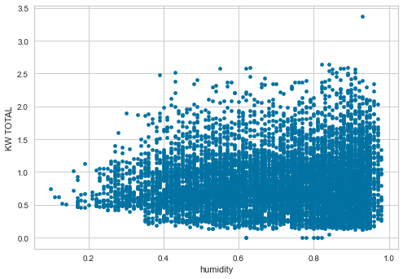

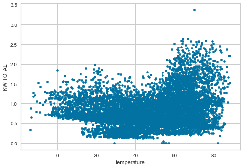

```python
df.plot.scatter(x = 'humidity', y = 'KW TOTAL')
df.plot.scatter(x = 'temperature', y = 'KW TOTAL')
```

## There are now 2 data frames:

1) KW_VS_Weather : KW total consumption Versus weather features , This dataset will be used in our prediction model  
2) df : includes everything which will be used in visualization

```python
KW_VS_Weather=pd.merge(Total_kw,meter_data1,how='left',on='Date & Time')# Total KW VS WEATHER DATASET
```

```python
KW_VS_Weather.head() # test
```

| Date & Time | KW TOTAL | temperature | humidity | visibility | apparentTemperature | pressure | windSpeed | cloudCover | windBearing | precipIntensity | dewPoint | precipProbability |
| --- | --- | --- | --- | --- | --- | --- | --- | --- | --- | --- | --- | --- |
| 2014-01-01 00:00:00 | 0.755914 | 16.67 | 0.53 | 10.0 | 3.95 | 1022.69 | 11.23 | 0.00 | 271.0 | 0.0 | 2.41 | 0.0 |
| 2014-01-01 01:00:00 | 0.717335 | 16.19 | 0.52 | 10.0 | 4.18 | 1022.58 | 9.92 | 0.02 | 268.0 | 0.0 | 1.68 | 0.0 |
| 2014-01-01 02:00:00 | 0.642693 | 15.69 | 0.55 | 10.0 | 4.41 | 1023.61 | 8.72 | 0.00 | 266.0 | 0.0 | 2.59 | 0.0 |
| 2014-01-01 03:00:00 | 0.598014 | 15.29 | 0.58 | 10.0 | 4.29 | 1024.31 | 8.25 | 0.00 | 269.0 | 0.0 | 3.29 | 0.0 |
| 2014-01-01 04:00:00 | 0.603914 | 15.37 | 0.60 | 10.0 | 5.12 | 1024.51 | 7.38 | 0.06 | 266.0 | 0.0 | 3.95 | 0.0 |

# Visualization for insights :

```python
df
```

| Date & Time | FurnaceHRV [kW] | CellarOutlets [kW] | WashingMachine [kW] | FridgeRange [kW] | DisposalDishwasher [kW] | KitchenLights [kW] | BedroomOutlets [kW] | BedroomLights [kW] | MasterOutlets [kW] | MasterLights [kW] | ... | humidity | visibility | apparentTemperature | pressure | windSpeed | cloudCover | windBearing | precipIntensity | dewPoint | precipProbability |
| --- | --- | --- | --- | --- | --- | --- | --- | --- | --- | --- | --- | --- | --- | --- | --- | --- | --- | --- | --- | --- | --- |
| 2014-01-01 00:00:00 | 0.188748 | 0.059672 | 0.005683 | 0.050515 | 0.005490 | 0.008677 | 0.020511 | 0.006884 | 0.049120 | 0.010139 | ... | 0.53 | 10.00 | 3.95 | 1022.69 | 11.23 | 0.00 | 271.0 | 0.0 | 2.41 | 0.0 |
| 2014-01-01 01:00:00 | 0.158467 | 0.059220 | 0.005653 | 0.048434 | 0.005477 | 0.003123 | 0.020511 | 0.004873 | 0.052081 | 0.010089 | ... | 0.52 | 10.00 | 4.18 | 1022.58 | 9.92 | 0.02 | 268.0 | 0.0 | 1.68 | 0.0 |
| 2014-01-01 02:00:00 | 0.111822 | 0.042478 | 0.005586 | 0.043357 | 0.005429 | 0.003115 | 0.020398 | 0.004841 | 0.048918 | 0.010002 | ... | 0.55 | 10.00 | 4.41 | 1023.61 | 8.72 | 0.00 | 266.0 | 0.0 | 2.59 | 0.0 |
| 2014-01-01 03:00:00 | 0.068529 | 0.041506 | 0.005560 | 0.044769 | 0.005432 | 0.003131 | 0.020532 | 0.004846 | 0.048724 | 0.010033 | ... | 0.58 | 10.00 | 4.29 | 1024.31 | 8.25 | 0.00 | 269.0 | 0.0 | 3.29 | 0.0 |
| 2014-01-01 04:00:00 | 0.074540 | 0.038502 | 0.005565 | 0.044778 | 0.005469 | 0.004444 | 0.020642 | 0.004870 | 0.048807 | 0.010085 | ... | 0.60 | 10.00 | 5.12 | 1024.51 | 7.38 | 0.06 | 266.0 | 0.0 | 3.95 | 0.0 |
| ... | ... | ... | ... | ... | ... | ... | ... | ... | ... | ... | ... | ... | ... | ... | ... | ... | ... | ... | ... | ... | ... |
| 2014-12-31 19:00:00 | 0.197351 | 0.043991 | 0.000264 | 0.000091 | 0.000064 | 0.000016 | 0.011345 | 0.004703 | 0.012774 | 0.008886 | ... | 0.66 | 10.00 | 28.15 | 1017.97 | 5.89 | 0.31 | 263.0 | 0.0 | 23.44 | 0.0 |
| 2014-12-31 20:00:00 | 0.194519 | 0.058191 | 0.000262 | 0.000090 | 0.000065 | 0.000017 | 0.011288 | 0.004708 | 0.012895 | 0.008936 | ... | 0.65 | 10.00 | 9.52 | 1021.99 | 3.61 | 0.02 | 215.0 | 0.0 | 5.78 | 0.0 |
| 2014-12-31 21:00:00 | 0.130979 | 0.059388 | 0.000166 | 0.000075 | 0.000058 | 0.000017 | 0.011380 | 0.004721 | 0.012992 | 0.008961 | ... | 0.73 | 9.98 | 6.57 | 1021.70 | 4.13 | 0.04 | 200.0 | 0.0 | 6.56 | 0.0 |
| 2014-12-31 22:00:00 | 0.159687 | 0.047227 | 0.000155 | 0.000079 | 0.000058 | 0.000016 | 0.011300 | 0.004711 | 0.012858 | 0.008918 | ... | 0.74 | 10.00 | 3.66 | 1020.74 | 5.13 | 0.22 | 210.0 | 0.0 | 5.62 | 0.0 |
| 2014-12-31 23:00:00 | 0.112274 | 0.042024 | 0.000101 | 0.000069 | 0.000053 | 0.000017 | 0.011242 | 0.004712 | 0.012821 | 0.008917 | ... | 0.74 | 10.00 | 4.24 | 1019.83 | 5.41 | 0.05 | 213.0 | 0.0 | 6.43 | 0.0 |

8760 rows × 26 columns

```python
# to unify time observations into monthly samples :
df_resampled=df.resample('M',convention='end').mean()
```

```python
df_resampled.head()
```

| Date & Time | FurnaceHRV [kW] | CellarOutlets [kW] | WashingMachine [kW] | FridgeRange [kW] | DisposalDishwasher [kW] | KitchenLights [kW] | BedroomOutlets [kW] | BedroomLights [kW] | MasterOutlets [kW] | MasterLights [kW] | ... | humidity | visibility | apparentTemperature | pressure | windSpeed | cloudCover | windBearing | precipIntensity | dewPoint | precipProbability |
| --- | --- | --- | --- | --- | --- | --- | --- | --- | --- | --- | --- | --- | --- | --- | --- | --- | --- | --- | --- | --- | --- |
| 2014-01-31 | 0.199520 | 0.057397 | 0.014737 | 0.073129 | 0.028663 | 0.071436 | 0.035500 | 0.014305 | 0.073898 | 0.022156 | ... | 0.659422 | 9.009328 | 25.867930 | 1015.477258 | 6.318710 | 0.167398 | 210.805108 | 0.001292 | 20.996465 | 0.038051 |
| 2014-02-28 | 0.178500 | 0.057965 | 0.011467 | 0.068950 | 0.026205 | 0.068680 | 0.036867 | 0.012613 | 0.077663 | 0.021430 | ... | 0.665119 | 8.320610 | 28.311890 | 1014.843795 | 7.430268 | 0.187649 | 205.608631 | 0.002977 | 23.549568 | 0.067098 |
| 2014-03-31 | 0.180724 | 0.058809 | 0.011278 | 0.071671 | 0.029309 | 0.067117 | 0.040964 | 0.013882 | 0.081753 | 0.020367 | ... | 0.632298 | 9.063629 | 29.836048 | 1016.207312 | 7.607567 | 0.191320 | 223.115591 | 0.003837 | 23.364126 | 0.068454 |
| 2014-04-30 | 0.158822 | 0.061477 | 0.009272 | 0.072997 | 0.028848 | 0.064196 | 0.037091 | 0.014444 | 0.074581 | 0.024302 | ... | 0.630014 | 9.429542 | 43.137528 | 1018.155375 | 7.263583 | 0.174077 | 198.558333 | 0.004343 | 32.560806 | 0.091819 |
| 2014-05-31 | 0.217923 | 0.065461 | 0.010250 | 0.076403 | 0.027884 | 0.062976 | 0.039633 | 0.013389 | 0.063795 | 0.018886 | ... | 0.693777 | 9.226976 | 52.615484 | 1017.110847 | 6.028548 | 0.231109 | 192.088710 | 0.002899 | 42.786613 | 0.066546 |

5 rows × 26 columns

# Visualization:

Assuming that the house owner wants consumption trend for each appliacnce sesnor feedback + Weather features

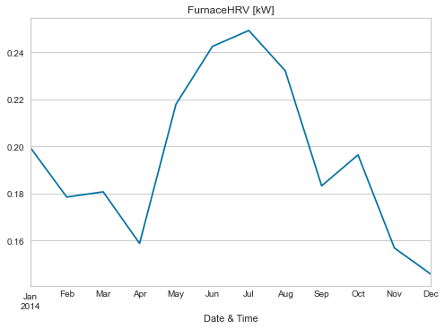

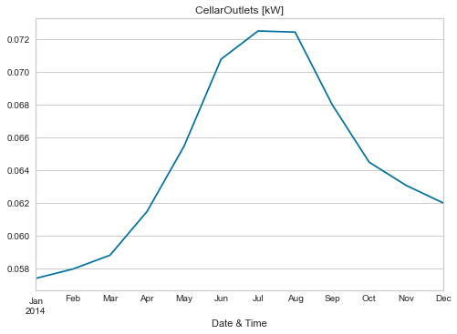

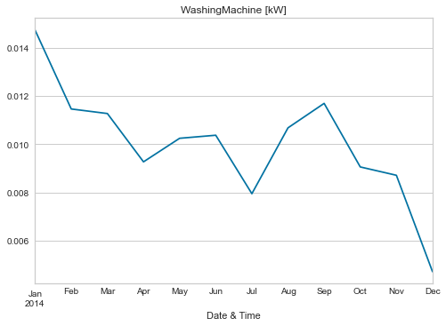

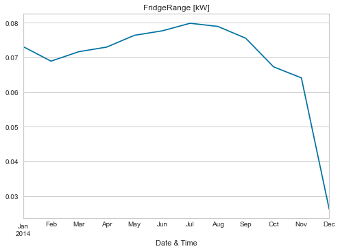

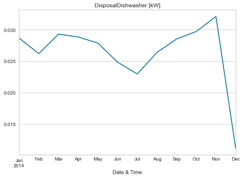

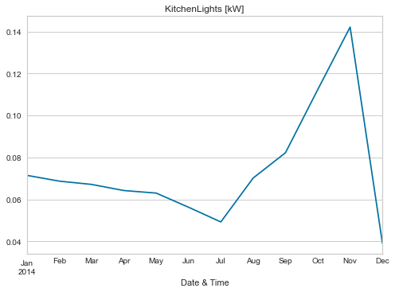

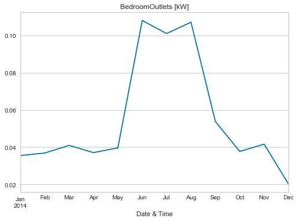

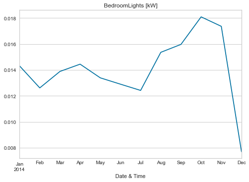

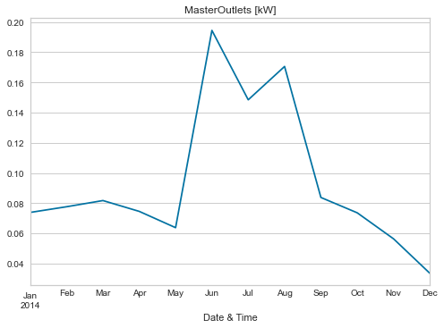

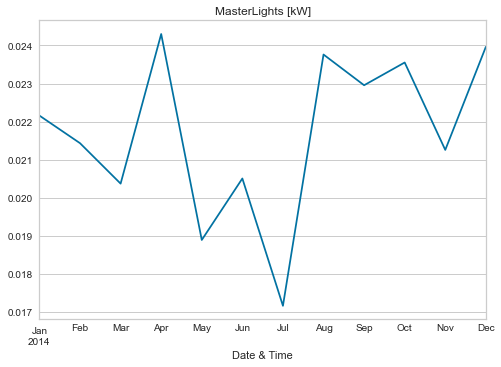

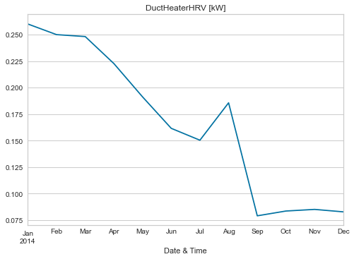

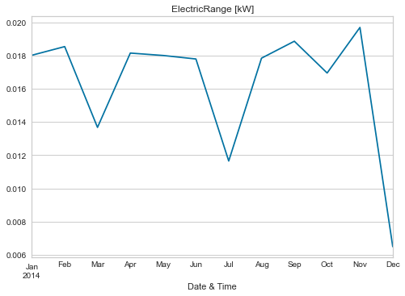

[14 more figures not shown]

```python
plt.figure(figsize=(10,20))
for i in range(len(df_resampled.columns)):
    plt.figure()
    df_resampled.iloc[:,i].plot()
    plt.title(df.columns[i])
    warnings.filterwarnings("ignore")
plt.tight_layout();
```

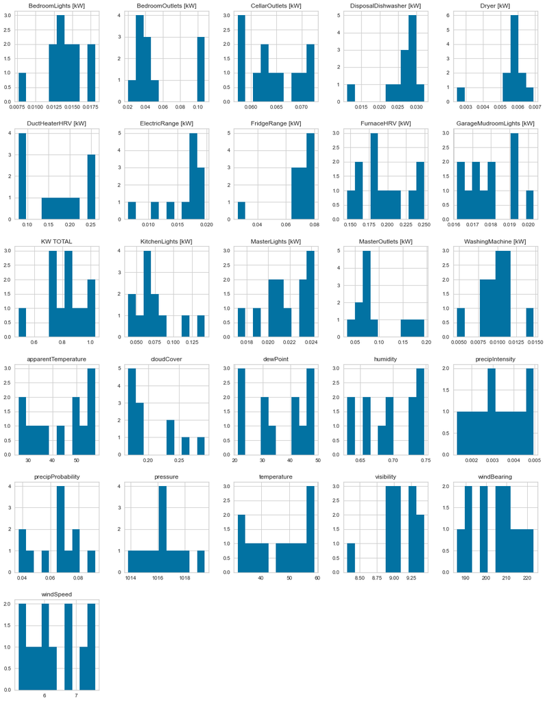

```python
#Independent Variable distribution
df_resampled.hist(figsize = (18,24)) ;
```

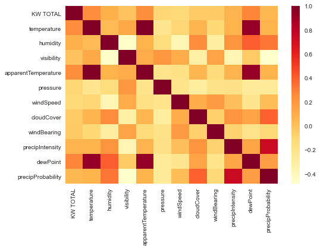

```python
#Heat Map
sns.heatmap(KW_VS_Weather.corr(), annot=False, cmap="YlOrRd")
plt.show()
```

# Prediction Model :

a) X-Y split  
b) Features standarization  
c) Features reduction  
d)Train-Test split  
e)Build the prediction model

```python
#Standardization to make all features on the same scale

Y=KW_VS_Weather['KW TOTAL']# label that I want to predict
X=KW_VS_Weather.iloc[:,1:]#features using iloc using all except the 1st one'Total kw' which is the target variable
sc=StandardScaler()#standardization function
X_std=sc.fit_transform(X) #fit the standardization on our features
```

```python
#drop null values 'not too many'
X_std=pd.DataFrame(X_std,columns=X.columns,index=X.index)
X_std=X_std.dropna()
Y=Y.dropna()
```

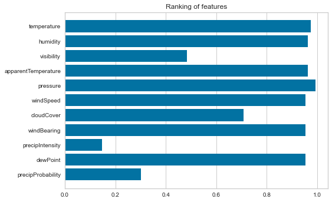

```python
visualizer=Rank1D() #features reduction to choose important features based on ranking
visualizer.fit(X_std,Y) # fit the data to visualizer
visualizer.transform(X_std) # transform the data
custom_viz = visualizer.ax
custom_viz.set_title("Ranking of features")
custom_viz.figure.show()
  # plot the data need sorting
```

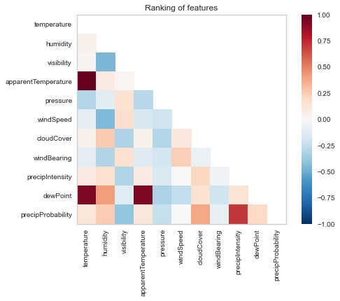

```python
visualizer=Rank2D() #features reduction to choose important features based on ranking
visualizer.fit(X_std,Y) # fit the data to visualizer
visualizer.transform(X_std) # transform the data
custom_viz = visualizer.ax
custom_viz.set_title("Ranking of features")
custom_viz.figure.show()
  # plot the data need sorting
```